# My Pokémon Boxes — Exporatory Data Analysis

### Heatmap

**I’ll admit, making a heatmap using base R was a lot more difficult than I realized.** So much has to go into properly formatting whatever you’re putting in the x axis if your data isn’t properly aggregated. If you’re looking to make more nuanced heatmaps(), I recommend heatmap2() and pheatmap().

**Firstly, you have to make sure all the variables you’re putting into the heatmap are numeric, due to the design of how the chart works.** So if you have variables that are non-numeric like character-based columns that you want to have accounted for, you’ll need to make counts for each instance and then coalesce them into the main data set you want to chart.

Here we go!

```r
# Subset main dataset
CrystalBoxHM <-  subset(CrystalBox[,c(3:4,9:10,12:17,19,21:31)])

# Edit the source data set for use with the heatmap, as heatmaps can only be used with matrices containing
# numeric variables
```

```r
 #Replace NAs with blank spaces for sum functions below

CrystalBoxHM[,2] <-
   replace(CrystalBoxHM$Type2,is.na(CrystalBoxHM$Type2),"")


 #Make Type columns

CrystalBoxHM2 <- unique( CrystalBoxHM[ , 1 ] )
CrystalBoxHM2 <- as.data.frame(CrystalBoxHM2)

CrystalBoxHM2$Type2 <- NA
colnames(CrystalBoxHM2) <- c("Type1", "Type2")
CrystalBoxHM2$Type2 = CrystalBoxHM2$Type1  #Run first

CrystalBoxHM2 <- CrystalBoxHM2 %>% add_row(Type1 = "Flying")
CrystalBoxHM2$Type2 = CrystalBoxHM2$Type1 #Run again

#See above, since the main data set doesn't account for Flying types in Type 1 as they're no pure Flying types in all of Pokémon.

#Make counts of Type 1 & 2 columns

CrystalBoxHM2$Type1_Count <-
   sapply(CrystalBoxHM2[,1], function(string)
     sum(string == CrystalBoxHM[,1]))

CrystalBoxHM2$Type2_Count <-
   sapply(CrystalBoxHM2[,2], function(string)
     sum(string == CrystalBoxHM[,2]))

#Edit row names for heatmap

row.names(CrystalBoxHM2) <- c("Psychic",  "Bug", "Normal", "Fire",
                                    "Ground", "Water",  "Electric",
                                    "Poison", "Dragon", "Ice", "Dark",
                                    "Fighting", "Rock", "Steel",  "Grass",
                                    "Ghost", "Flying")

#Make other columns for the matrix that the heatmap will be based on...


#Make Type counts for the other data set we subsetted originally:

CrystalBoxHM$Type1_Count <-
   sapply(CrystalBoxHM[,1], function(string)
     sum(string == CrystalBoxHM[,1]))


CrystalBoxHM$Type2_Count <-
   sapply(CrystalBoxHM[,2], function(string)
     sum(string == CrystalBoxHM[,2]))

#Splitting data, merging new datasets, summarizing and subsetting:

Type1_meanEXP <-
   CrystalBoxHM %>% group_by(Type1) %>% summarize(mean_EXP = mean(EXP))

Type1_meanEXP <-
   Type1_meanEXP %>% remove_rownames %>%
   column_to_rownames(var = "Type1") %>%  as.data.frame()

meanEXP2 <- merge(CrystalBoxHM2, Type1_meanEXP, by = 0, all = TRUE)

meanEXP2 <-
   meanEXP2 %>% remove_rownames %>%
   column_to_rownames(var = "Row.names") %>%  as.data.frame()

#Note above that we must change the row names to the types that will display in the heatmap, because remember, heatmaps can only be used with dataset that contain columns with only numeric properties. Row names are not affected by this.

#Merge and null unneeded columns

meanEXP2[,1:2] <- NULL

#New data with all the means we need

all_means <- subset(CrystalBoxHM, select = c(Type1:Type2, Level, HP:SPE))

all_means[, 10:16] <- colMeans(x = all_means[, 3:9])

all_means[, 3:9] <- NULL

#Rename rows to proper averages:

all_means <- all_means %>%
   rename(
     Level_Avg = V10,
     HP_Avg = V11,
     ATK_Avg = V12,
     DEF_Avg = V13,
     SPA_Avg = V14,
     SPD_Avg = V15,
     SPE_Avg = V16
   )

#Re-summarise all the means in our group

all_means <-
   all_means %>% group_by(Type1) %>% summarise_all(mean)

all_means[, 2] <- NULL

all_means <-
   all_means %>% remove_rownames %>% column_to_rownames(var = "Type1") %>%  as.data.frame()

#Merge everything and fix row names:

meanEXP2 <- merge(meanEXP2, all_means,  by = 0, all = TRUE)


meanEXP2 <-
   meanEXP2 %>% remove_rownames %>% column_to_rownames(var = "Row.names") %>%
   as.data.frame()

CrystalBoxHM3 <- meanEXP2 #I renamed the merged dataset to maintain consistency.
```

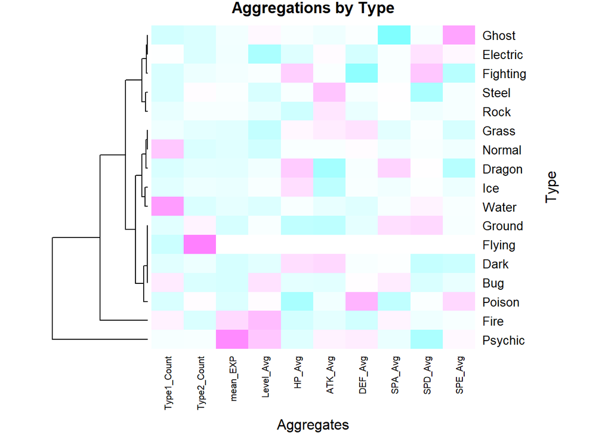

```r
#The heatmap itself

par(cex.main = .85)

heatmap(as.matrix(x = CrystalBoxHM3), scale="col",
         margins = c(6, 6),
         Colv = NA,
         na.rm = TRUE,
         main = "Aggregations by Type",
         xlab= "Aggregates",
         ylab= "Type",
         cexCol=.75, col = cm.colors(256))
```

```r
#Note how I edited the code to remove the column dendrogram from the chart.
```

…

# Outro

$~$

When it comes to the intricate details of Pokémon, you’ll start to unravel many layers to a game that seems rather innocuous on the outside.

Frankly, when I started to delve deeper and deconstruct one of my all-time favorite games in this manner; it took a good amount of self-reflection. Data is certainly something I find passion in doing well, but sometimes when it comes to games—–the fun comes in the mystery that comes with discovering novel things, and joy that is found in the experience you have in the present moment.

While the fun of my childhood self playing Pokémon will always be seeped in nostalgia, through finding novel experiences via my pursuits in data and uncovering useful insights—I hope that can give me a similar feeling in my adult life.

I’ll always appreciate what Satoshi Tajiri gave me and millions of other youth worldwide.

$~$

*Thank you for reading,* *Bruce A. Lee*